# **Salary and Benefit Analysis Report**

Final Project

Yongqiao LIANG

4/9/2022

# 1 **Introduction**

Building a good compensation structure ensures effective labor cost distribution and gives competitive salary and benefit for attracting and remaining high quality talents. A compensation strategy that is data-driven and forward-thinking. I am going for a job interview Compensation and Benefit Analyst position next Wednesday and I never worked on this field, even though there are some common missions as the other analyst positions. Hence, for well preparing interview questions, I’d like to take advantage of this project and choose compensation data set to analyze and have more particular knowledge into it.

# 2 **Presentation and description of the problem**

## 2.1 Research questions

1. The latest compensation component proportion +. Salary and Benefit main component weight +. Department labor cost weight
2. Labor cost distribution analysis +. Job Family labor cost weight by top 3 Departments +. Top 5 Job family labor cost distribution analysis
3. salary further tendency +. total compensation from 2013 to 2020 by line chart +. total Compensation prediction by unary linear regression

```
## # A tibble: 678,524 × 22
##    `Organization Group Code` `Job Family Code` `Job Code` `Year Type`  Year
##    <chr>                     <chr>             <chr>      <chr>       <dbl>
##  1 01                        1000              1021       Calendar     2013
##  2 01                        1000              1023       Calendar     2013
##  3 01                        1000              1031       Calendar     2013
##  4 01                        1000              1054       Calendar     2013
##  5 01                        1000              1062       Calendar     2013
##  6 01                        1000              1064       Calendar     2013
##  7 01                        1000              1070       Calendar     2013
##  8 01                        1000              1094       Calendar     2013
##  9 01                        1200              1232       Calendar     2013
## 10 01                        1600              1654       Calendar     2013
## # … with 678,514 more rows, and 17 more variables: Organization Group <chr>,
## #   Department Code <chr>, Department <chr>, Union Code <chr>, Union <chr>,
## #   Job Family <chr>, Job <chr>, Employee Identifier <dbl>, Salaries <dbl>,
## #   Overtime <dbl>, Other Salaries <dbl>, Total Salary <dbl>, Retirement <dbl>,
## #   Health and Dental <dbl>, Other Benefits <dbl>, Total Benefits <dbl>,
## #   Total Compensation <dbl>
```

# 3 **Presentation of the data**

## 3.1 Usability of the dataset

The csv file “Employee_Salary_Compensation” has been collected in Kaggle due to its association,complexity, long time span and clear interpretation of each variables. The high download per view ratio (11%) and usability score (9.41) in Kaggle also indicates its availability. There were 2 contributors who used it and worked in compensation prediction with python.

## 3.2 Description of dataset

The csv file “Employee_Salary_Compensation” is a data set about salary and benefit of San Francisco Controller’s Office from 2013 to 2020, containing 22 columns and 678524 rows.

1. **Organization Group Code**: Org Group is a group of Departments. For example, the Public Protection Org Group includes departments such as the Police, Fire, Adult Probation, District Attorney, and Sheriff.
2. **Job Family Code**: Job Family combines similar Jobs into meaningful groups.
3. **Job Code**: Jobs are defined by the Human Resources classification unit. Examples include gardeners, police officers, and accountants.
4. **Year Type**: Fiscal (July through June) or Calendar (January through December)
5. **Year**: An accounting period of 12 months. The City and County of San Francisco operate on a fiscal year that begins on July 1 and ends on June 30 the following year. The Fiscal Year ending June 30, 2012, is represented as FY2011-2012.
6. **Organization Group**: Org Group is a group of Departments. For example, the Public Protection Org Group includes departments such as the Police, Fire, Adult Probation, District Attorney, and Sheriff.
7. **Department Code**: Departments are the primary organizational unit used by the City and County of San Francisco. Examples include Recreation and Parks, Public Works, and the Police Department.
8. **Department**: Departments are the primary organizational unit used by the City and County of San Francisco. Examples include Recreation and Parks, Public Works, and the Police Department.
9. **Union Code**: Unions represent employees in collective bargaining agreements. A job belongs to one union, although some jobs are unrepresented (usually temporarily).
10. **Union**: Unions represent employees in collective bargaining agreements. A job belongs to one union, although some jobs are unrepresented (usually temporarily).
11. **Job Family**: Job Family combines similar Jobs into meaningful groups.
12. **Job**: Jobs are defined by the Human Resources classification unit. Examples include gardeners, police officers, and accountants.
13. **Employee Identifier**: Each distinct number in the “Employee Identifier” column represents one employee. These identifying numbers are not meaningful but rather are randomly assigned for the purpose of building this dataset. Employee ID has been included here to allow users to reconstruct the original report. Note that each employee’s identifier will change each time this dataset is updated, so comparisons by employee across multiple versions of the dataset are not possible.
14. **Salaries**: Normal salaries paid to permanent or temporary City employees.
15. **Overtime**: Amounts paid to City employees working in excess of 40 hours per week.
16. **Other Salaries**: Various irregular payments made to City employees including premium pay, incentive pay, or other one-time payments.
17. **Total Salary**: The sum of all salaries paid to City employees.
18. **Retirement**: City contributions to employee retirement plans.
19. **Health and Dental**: City-paid premiums to health and dental insurance plans covering City employees. To protect confidentiality as legally required, pro-rated citywide averages are presented in lieu of employee-specific health and dental benefits.
20. **Other Benefits**: Mandatory benefits paid on behalf of employees, such as Social Security (FICA and Medicare) contributions, unemployment insurance premiums, and minor discretionary benefits not included in the above categories.
21. **Total Benefits**: The sum of all benefits paid to City employees.
22. **Total Compensation**: The sum of all salaries and benefits paid to City employees.

The columns are reordered and arrange code and name column together to better understand.

```r
salary <-rawdata %>% select(c(1,6,7,8,9,10,2,11,3,12,4,5,13:22))
salary
```

```
## # A tibble: 678,524 × 22
##    `Organization Gro… `Organization G… `Department Cod… Department  `Union Code`
##    <chr>              <chr>            <chr>            <chr>       <chr>
##  1 01                 Public Protecti… ADP              ADP Adult … 021
##  2 01                 Public Protecti… ADP              ADP Adult … 021
##  3 01                 Public Protecti… ADP              ADP Adult … 021
##  4 01                 Public Protecti… ADP              ADP Adult … 021
##  5 01                 Public Protecti… ADP              ADP Adult … 021
##  6 01                 Public Protecti… ADP              ADP Adult … 021
##  7 01                 Public Protecti… ADP              ADP Adult … 021
##  8 01                 Public Protecti… ADP              ADP Adult … 021
##  9 01                 Public Protecti… ADP              ADP Adult … 021
## 10 01                 Public Protecti… ADP              ADP Adult … 021
## # … with 678,514 more rows, and 17 more variables: Union <chr>,
## #   Job Family Code <chr>, Job Family <chr>, Job Code <chr>, Job <chr>,
## #   Year Type <chr>, Year <dbl>, Employee Identifier <dbl>, Salaries <dbl>,
## #   Overtime <dbl>, Other Salaries <dbl>, Total Salary <dbl>, Retirement <dbl>,
## #   Health and Dental <dbl>, Other Benefits <dbl>, Total Benefits <dbl>,
## #   Total Compensation <dbl>
```

# 4 **Exploratory data analysis**

## 4.1 The latest compensation component proportion

```r
prop_2020 <- salary %>%
            select(`Year`,`Total Salary`,`Total Benefits`,`Total Compensation`) %>%
            dplyr::filter(`Year`== 2020) %>%
            mutate(global_salary_by_compen=round(`Total Salary`/`Total Compensation`,2)) %>%
            mutate(global_benefits_by_compen=round(`Total Benefits`/`Total Compensation`,2))

mean(prop_2020$global_salary_by_compen,na.rm=T)
```

```
## [1] 0.7351232
```

```r
mean(prop_2020$global_benefits_by_compen,na.rm=T)
```

```
## [1] 0.2648768
```

## 4.2 Salaries, Overtime and Other salaries from Total Salary

```r
## Salary Composition by total salary
# Salaries
salary_by_total_salary <- salary %>%
            select(`Organization Group Code`,Year,`Total Salary`,`Salaries`) %>%
            dplyr::filter(`Year`== 2020) %>%
            dplyr::filter(`Salaries`>`Total Salary`) %>%
            dplyr::filter(`Organization Group Code`=="01") %>%
            mutate(salary_by_total_salary=abs(`Salaries`)/abs(`Total Salary`))
mean(salary_by_total_salary$salary_by_total_salary,na.rm=T)
```

```
## [1] 0.8407634
```

```r
# Overtime
overtime_by_total_salary <- salary %>%
            select(`Organization Group Code`,`Year`,`Total Salary`,`Overtime`) %>%
            dplyr::filter(`Year`== 2020) %>%
            dplyr::filter(`Organization Group Code`=="01") %>%
            mutate(overtime_by_total_salary=abs(`Overtime`)/abs(`Total Salary`))
mean(overtime_by_total_salary$overtime_by_total_salary,na.rm=T)
```

```
## [1] 0.1028666
```

```r
# other salaries
other_by_total_salary <- salary %>%
            select(`Organization Group Code`,`Year`,`Total Salary`,`Other Salaries`) %>%
            dplyr::filter(`Year`== 2020) %>%
            dplyr::filter(`Organization Group Code`=="01") %>%
            dplyr::filter(`Other Salaries`<`Total Salary`) %>%
            mutate(overtime_by_total_salary=abs(`Other Salaries`)/abs(`Total Salary`))
mean(other_by_total_salary$overtime_by_total_salary,na.rm=T)
```

```
## [1] 0.06171847
```

## 4.3 Retirement, health & dental and Other benefits from Total Benefits

```r
# retirement
retiremt_by_total_benefit <- salary %>%
  select(`Organization Group Code`, Year, Retirement,`Total Benefits`) %>%
  dplyr::filter(`Year`== 2020) %>%
  dplyr::filter(`Organization Group Code`=="01") %>%
  mutate(retiremt_by_total_benefit=abs(`Retirement`)/abs(`Total Benefits`))
mean(retiremt_by_total_benefit$retiremt_by_total_benefit,na.rm=T)
```

```
## [1] 0.5339047
```

```r
# health & dental
health_by_total_benefit <- salary %>%
  select(`Organization Group Code`, Year, `Health and Dental`,`Total Benefits`) %>%
  dplyr::filter(`Year`== 2020) %>%
  dplyr::filter(`Organization Group Code`=="01") %>%
  mutate(health_by_total_benefit=abs(`Health and Dental`)/abs(`Total Benefits`))
mean(health_by_total_benefit$health_by_total_benefit,na.rm=T)
```

```
## [1] 0.3271636
```

```r
# other benefits
other_by_total_benefit <- salary %>%
  select(`Organization Group Code`, Year, `Other Benefits`,`Total Benefits`) %>%
  dplyr::filter(`Year`== 2020) %>%
  dplyr::filter(`Organization Group Code`=="01") %>%
  mutate(other_by_total_benefit=abs(`Other Benefits`)/abs(`Total Benefits`))
mean(other_by_total_benefit$other_by_total_benefit,na.rm=T)
```

```
## [1] 0.1389577
```

## 4.4 The most labor cost weighted department

In organization Public Protection, the top 3 weighted departments are Police, Fire Department and Sheriff that have taken respectively 40.05%, 26.47% and 14.79%. Department of Police Accountability has the fewest because of the lowest number of employees.

```r
# Organization 01
condition_table1 <- salary %>%
      dplyr::filter(Year=="2020") %>%
      dplyr::filter(`Organization Group Code`=="01")

depart_compen_prop <-
  aggregate(condition_table1$`Total Compensation`, by=list(department=condition_table1$Department),sum)

numberofEachDepart <- salary %>%
   dplyr::filter(Year=="2020") %>%
   dplyr::filter(`Organization Group Code`=="01") %>%
   group_by(Department) %>%
   summarise(numberofRow=n())
arrange(numberofEachDepart,desc(numberofRow))
```

```
## # A tibble: 10 × 2
##    Department                     numberofRow
##    <chr>                                <int>
##  1 Police                                6369
##  2 Fire Department                       3809
##  3 Sheriff                               2204
##  4 Trial Courts                          1010
##  5 District Attorney                      696
##  6 Dept of Emergency Management           642
##  7 Juvenile Court                         475
##  8 Public Defender                        419
##  9 Adult Probation                        356
## 10 Dept of Police Accountablility         113
```

```r
depart_compen_prop$Deprt_by_total <- round(prop.table(depart_compen_prop$x),4)
arrange(depart_compen_prop,desc(Deprt_by_total))
```

```
##                        department          x Deprt_by_total
## 1                          Police 1154588641         0.4005
## 2                 Fire Department  763008731         0.2647
## 3                         Sheriff  426522452         0.1479
## 4               District Attorney  122126056         0.0424
## 5                    Trial Courts  115664737         0.0401
## 6    Dept of Emergency Management  105331634         0.0365
## 7                 Public Defender   74156727         0.0257
## 8                  Juvenile Court   55173341         0.0191
## 9                 Adult Probation   49704319         0.0172
## 10 Dept of Police Accountablility   16651967         0.0058
```

## 4.5 Job Family labor cost weight by top 3 Departments

Among three most weighted departments, the table below shows the 6 job families, and it orders from the largest to smallest. The Police services from Police department occupied 41.09% because it has the largest number of employees; Fire service occupied 31.18% as the same reason. The Protection & Apprehension and Management and Airport Operation just occupied less than 5%.

```r
condition_table2 <- condition_table1 %>%
  select(`Organization Group Code`,Year,`Job Family Code`,`Job Family` ,`Total Compensation`,Department) %>%
  dplyr::filter(Year=="2020") %>%
  dplyr::filter(`Organization Group Code`=="01") %>%
  dplyr::filter(Department =="Police" |Department=="Fire Department" |Department== "Sheriff")

jobF_compen_prop <-
  aggregate(condition_table2$`Total Compensation`, by=list(jobF_code=condition_table2$`Job Family Code`,jobF=condition_table2$`Job Family`),sum)
jobF_compen_prop$JobF_by_total <- round(prop.table(jobF_compen_prop$x),4)
head(arrange(jobF_compen_prop,desc(JobF_by_total),5))
```

```
##   jobF_code                      jobF         x JobF_by_total
## 1      Q000           Police Services 963315253        0.4109
## 2      H000             Fire Services 730818457        0.3118
## 3      8300    Correction & Detention 392812425        0.1676
## 4      9200         Airport Operation  60934075        0.0260
## 5      0900                Management  27358718        0.0117
## 6      8200 Protection & Apprehension  26283618        0.0112
```

# 5 **Visualization of the data**

## 5.1 compensation distribition reasonability verification

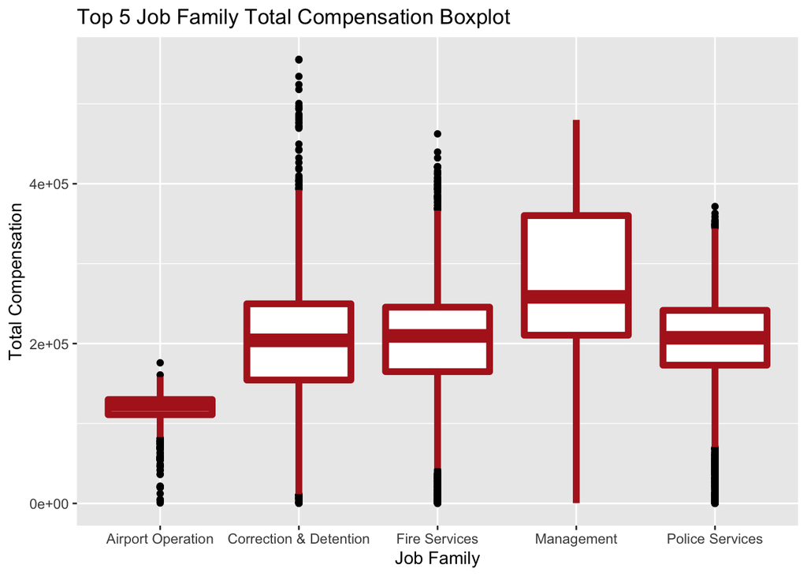

```r
condition_table3 <- salary %>%
  dplyr::filter(`Job Family Code`=="Q000"|`Job Family Code`=="H000"|
                `Job Family Code`=="8300" |
                `Job Family Code`=="9200"|`Job Family Code`=="0900") %>%
  dplyr::filter(Year=="2020") %>%
  dplyr::filter(`Organization Group Code`=="01") %>%
  dplyr::filter(Department =="Police" |Department=="Fire Department" |Department== "Sheriff")

ggplot(condition_table3, mapping=aes(x=`Job Family`,y=`Total Compensation`,options(scipen=200))) +
  geom_boxplot(color = "firebrick", shape = "diamond", size = 2,outlier.colour="black") +
  labs(title="Top 5 Job Family Total Compensation Boxplot",x = "Job Family", y = "Total Compensation") +
  scale_color_manual(values=c("#999999", "#E69F00", "#56B4E9"))
```

## 5.2 Total Compensation Tendency from 2013 to 2020

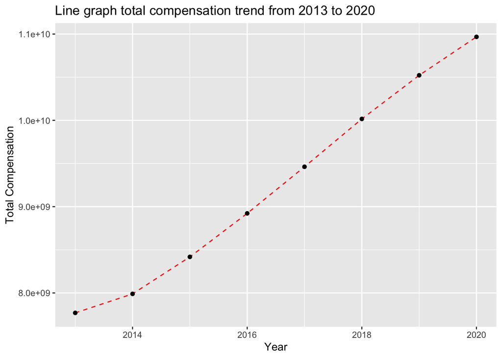

```r
total_compen_13to20 <- aggregate(salary$`Total Compensation`,by=list(salary$Year),sum)
ggplot(total_compen_13to20,mapping=aes(x=`Group.1`,y=x,group=1))+
  geom_line(linetype = "dashed",color="red")+
  geom_point() +
  labs(title="Line graph total compensation trend from 2013 to 2020",x = "Year", y = "Total Compensation")
```

## 5.3 Total Compensation forecasting by unary linear regression

I used ggplot2 to plot the linear regression into graph below and we can see that the blue line represents a predictive line, and the black dots are the value of real total compensation. The black dots are very closed to the blue line, even it overlaps. Obviously, the linear model has high accuracy for predicting the further years total compensation.

```r
relation <- lm(x~Group.1,total_compen_13to20)
relation
```

```
##
## Call:
## lm(formula = x ~ Group.1, data = total_compen_13to20)
##
## Coefficients:
## (Intercept)      Group.1
##  -9.603e+11    4.808e+08
```

```r
new <- data.frame(Group.1=c(2020))
pre <- predict(relation,new)
pre
```

```
##           1
## 10941205638
```

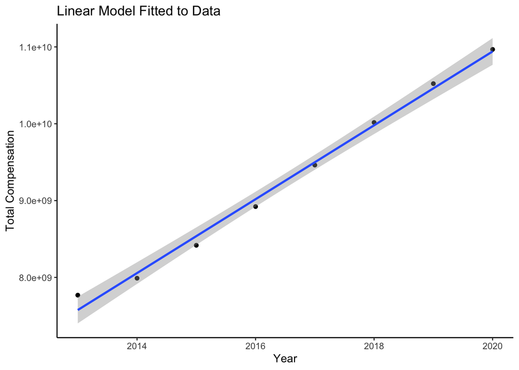

```r
ggplot(data=relation,aes(x=Group.1,y=x)) +
  geom_point() +
  stat_smooth(method="lm") +
  theme(panel.background=element_rect(fill="white"),
                                      axis.line.x=element_line(),
                                      axis.line.y=element_line()) +
  ggtitle("Linear Model Fitted to Data") +
  labs(x = "Year", y = "Total Compensation")
```

# 6 **Interpretation/Conclusion**

In 2020, Organization Public Protection’s 2 main expended components of total compensation are salary and retirement. And the 3 key departments Police, Fire Department and Sheriff occupied the most compensation and number of employees.

Among these 3 departments, Police services, fire services and Correction & Detection are the 3 main job services and weighted the most of total compensation. In other word, we can say that police services, fire services and correction & detection most need manpower.

From the perspective of salary compensation, these 3 services have similar median compensation, no matter the highest or lowest compensation. However, from the salary distribution of Correction & Detection, it has various compensation level for different positions, and it may cause unfair salary system within service and non-structural hierarchy. I suggest adjusting the service position structure for flat management.

# 7 **References**

The data set is found from the link below:

**(https://www.kaggle.com/datasets/siddheshera/san-francisco-employee-salary-compensation)**